# lab-6(faceting)

## Grouping for collective geoms

this code generates a scatter plot with points colored according to the variable z and connects these points with lines to show the sequence or trend based on their order in the data.

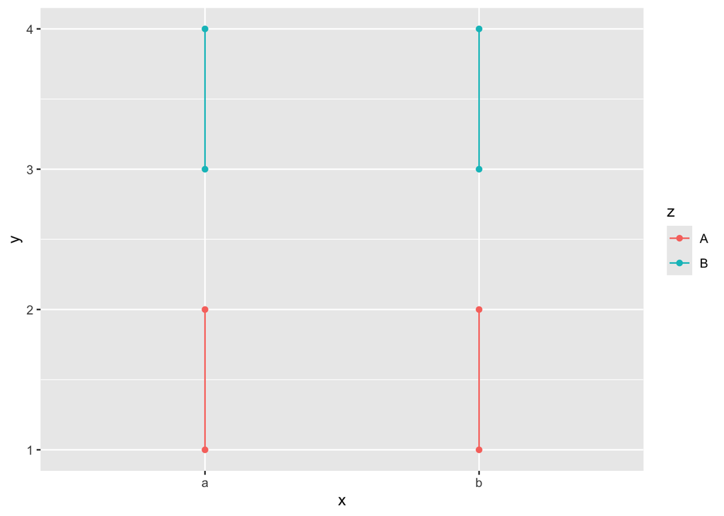

```r
ggplot(df, aes(x, y, color = z)) +
 geom_point() +
 geom_path()
```

this code creates a scatter plot where points are colored by z, and lines connect the points within each group defined by z. Each group will have a distinct line connecting its points, which helps visualize trends or paths for each category.

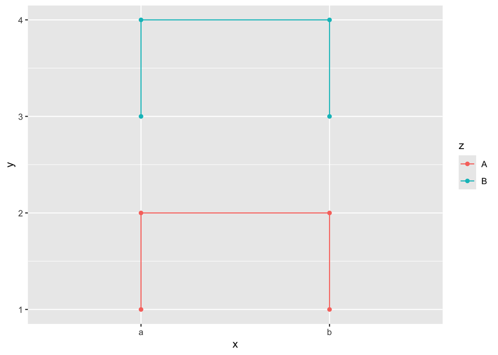

```r
ggplot(df, aes(x, y, color = z)) +
 geom_point() +
 geom_path(aes(group = z))
```

this code creates a scatter plot where points are colored based on the variable z, and a single line is drawn connecting all points in the dataset, since all points are grouped together under group = 10

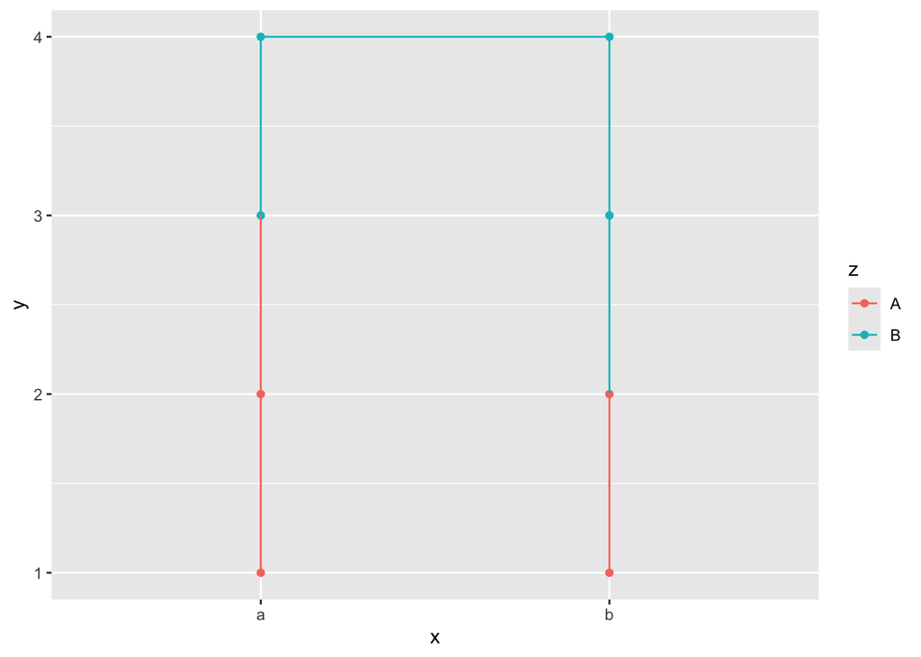

```r
ggplot(df, aes(x, y, color = z)) +
 geom_point() +
 geom_path(aes(group = 10))
```